# IMDB Movie Analysis

# About

This project is part of the first group homework of [Applied Statistics with R](https://mam2021.netlify.app/) taught by Professor Kostis Christodoulou at **London Business School**.

My collaborators are Alessandro Angeletti, Nitya Chopra, Johanna Jeffery, and Christopher Lewis. (Hail Group 13!)

# Let’s do this

We first get a sample of movies from the IMDB 5000 movie dataset.

```r
# The movie dataset is taken from the csv file "movies.csv"
movies <- read_csv(here::here("data", "movies.csv"))

# view the dataset
glimpse(movies)
head(movies)
skim(movies)
```

```r
movies <- read_csv(here::here("data", "movies.csv"))

# remove duplicates via distinct
skim(distinct(movies,title, keep_all = FALSE))
```

Data summary

| Name | distinct(movies, title, k… |
| --- | --- |
| Number of rows | 2907 |
| Number of columns | 2 |
| _______________________ |  |
| Column type frequency: |  |
| character | 1 |
| logical | 1 |
| ________________________ |  |
| Group variables | None |

**Variable type: character**

| skim_variable | n_missing | complete_rate | min | max | empty | n_unique | whitespace |
| --- | --- | --- | --- | --- | --- | --- | --- |
| title | 0 | 1 | 1 | 83 | 0 | 2907 | 0 |

**Variable type: logical**

| skim_variable | n_missing | complete_rate | mean | count |
| --- | --- | --- | --- | --- |
| keep_all | 0 | 1 | 0 | FAL: 2907 |

Next, we create a table of the number of movies by genre.

```r
movies_table <- movies %>%
  count(genre,
        wt = NULL,
        sort = TRUE)
# print
movies_table
```

```
## # A tibble: 17 x 2
##    genre           n
##    <chr>       <int>
##  1 Comedy        848
##  2 Action        738
##  3 Drama         498
##  4 Adventure     288
##  5 Crime         202
##  6 Biography     135
##  7 Horror        131
##  8 Animation      35
##  9 Fantasy        28
## 10 Documentary    25
## 11 Mystery        16
## 12 Sci-Fi          7
## 13 Family          3
## 14 Musical         2
## 15 Romance         2
## 16 Western         2
## 17 Thriller        1
```

Return on budget is calculated as the ratio between how much money a film made compared to the budget used during production

```r
# calculate average return on budget
# for each genre and displaying results in a table
gross_budget <- movies %>%
  group_by(genre) %>%
  summarise(average_gross = mean(gross,na.rm = TRUE),
            average_budget = mean(budget,na.rm = TRUE)) %>%
  mutate(return_on_budget = average_gross/average_budget) %>%
  arrange(desc(return_on_budget))

gross_budget
```

```
## # A tibble: 17 x 4
##    genre       average_gross average_budget return_on_budget
##    <chr>               <dbl>          <dbl>            <dbl>
##  1 Musical         92084000        3189500          28.9
##  2 Family         149160478.      14833333.         10.1
##  3 Western         20821884        3465000           6.01
##  4 Documentary     17353973.       5887852.          2.95
##  5 Horror          37713738.      13504916.          2.79
##  6 Fantasy         42408841.      17582143.          2.41
##  7 Comedy          42630552.      24446319.          1.74
##  8 Mystery         67533021.      39218750           1.72
##  9 Animation       98433792.      61701429.          1.60
## 10 Biography       45201805.      28543696.          1.58
## 11 Adventure       95794257.      66290069.          1.45
## 12 Drama           37465371.      26242933.          1.43
## 13 Crime           37502397.      26596169.          1.41
## 14 Romance         31264848.      25107500           1.25
## 15 Action          86583860.      71354888.          1.21
## 16 Sci-Fi          29788371.      27607143.          1.08
## 17 Thriller            2468         300000           0.00823
```

Next, we analyze the gross earnings of the top 15 directors (ranked by total earnings of the movies they produced).

```r
# calculate total gross earnings and mean, median and standard deviation by director
gross_directors <- movies %>%
  group_by(director) %>%
  summarise(total_gross = sum(gross,na.rm = TRUE),
            mean_gross = mean(gross,na.rm = TRUE),
            median_gross = median(gross,na.rm = TRUE),
            std_dev_gross = sd(gross,na.rm = TRUE)) %>%

  # select the top 15 items
  top_n(15,total_gross) %>%

  # arrange the items in descending order of total gross
  arrange(desc(total_gross))

gross_directors
```

```
## # A tibble: 15 x 5
##    director          total_gross mean_gross median_gross std_dev_gross
##    <chr>                   <dbl>      <dbl>        <dbl>         <dbl>
##  1 Steven Spielberg   4014061704 174524422.   164435221     101421051.
##  2 Michael Bay        2231242537 171634041.   138396624     127161579.
##  3 Tim Burton         2071275480 129454718.    76519172     108726924.
##  4 Sam Raimi          2014600898 201460090.   234903076     162126632.
##  5 James Cameron      1909725910 318287652.   175562880.    309171337.
##  6 Christopher Nolan  1813227576 226653447    196667606.    187224133.
##  7 George Lucas       1741418480 348283696    380262555     146193880.
##  8 Robert Zemeckis    1619309108 124562239.   100853835      91300279.
##  9 Clint Eastwood     1378321100  72543216.    46700000      75487408.
## 10 Francis Lawrence   1358501971 271700394.   281666058     135437020.
## 11 Ron Howard         1335988092 111332341    101587923      81933761.
## 12 Gore Verbinski     1329600995 189942999.   123207194     154473822.
## 13 Andrew Adamson     1137446920 284361730    279680930.    120895765.
## 14 Shawn Levy         1129750988 102704635.    85463309      65484773.
## 15 Ridley Scott       1128857598  80632686.    47775715      68812285.
```

We also review the ratings of all the movies by genre and create table with other details.

```r
# calculate minimum, maximum, average, median and standard deviations of ratings by genre
ratings_table <- movies %>%
  group_by(genre) %>%
  summarise(max_rating = max(rating),
            min_rating = min(rating,na.rm = FALSE),
            mean_rating = mean(rating,na.rm = TRUE),
            median_rating = median(rating,na.rm = TRUE),
            std_dev_rating = sd(rating,na.rm = TRUE)) %>%
  arrange(genre)

# display results in a table
ratings_table
```

```
## # A tibble: 17 x 6
##    genre       max_rating min_rating mean_rating median_rating std_dev_rating
##    <chr>            <dbl>      <dbl>       <dbl>         <dbl>          <dbl>
##  1 Action             9          2.1        6.23          6.3           1.03
##  2 Adventure          8.6        2.3        6.51          6.6           1.09
##  3 Animation          8          4.5        6.65          6.9           0.968
##  4 Biography          8.9        4.5        7.11          7.2           0.760
##  5 Comedy             8.8        1.9        6.11          6.2           1.02
##  6 Crime              9.3        4.8        6.92          6.9           0.849
##  7 Documentary        8.5        1.6        6.66          7.4           1.77
##  8 Drama              8.8        2.1        6.73          6.8           0.917
##  9 Family             7.9        5.7        6.5           5.9           1.22
## 10 Fantasy            7.9        4.3        6.15          6.45          0.959
## 11 Horror             8.5        3.6        5.83          5.9           1.01
## 12 Musical            7.2        6.3        6.75          6.75          0.636
## 13 Mystery            8.5        4.6        6.86          6.9           0.882
## 14 Romance            7.1        6.2        6.65          6.65          0.636
## 15 Sci-Fi             8.2        5          6.66          6.4           1.09
## 16 Thriller           4.8        4.8        4.8           4.8          NA
## 17 Western            7.3        4.1        5.70          5.70          2.26
```

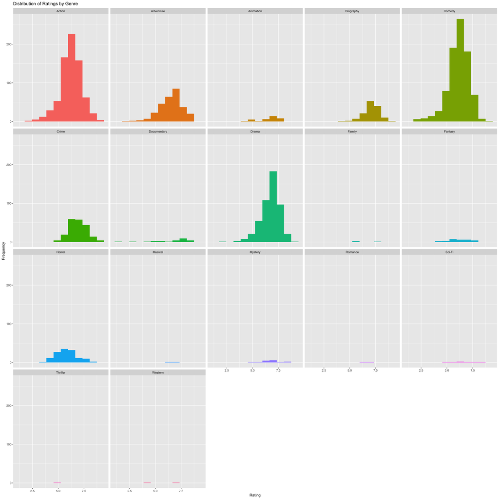

```r
# plote a histogram showing the distribution of ratings by genre
ratings_plot <- movies %>%
  ggplot(data = movies,
         mapping = aes(
           x = rating,
           fill = genre)) +
  geom_histogram(binwidth = 0.7) +
  facet_wrap(~genre) +
  labs(title = "Distribution of Ratings by Genre",
       x = "Rating",
       y = "Frequency") +
  theme(legend.position = "none") +
  NULL

ratings_plot
```

To determine whether there is a relationship between number of facebook likes the cast of a movie receives and the gross earnings of that movie, we plot the data as below -

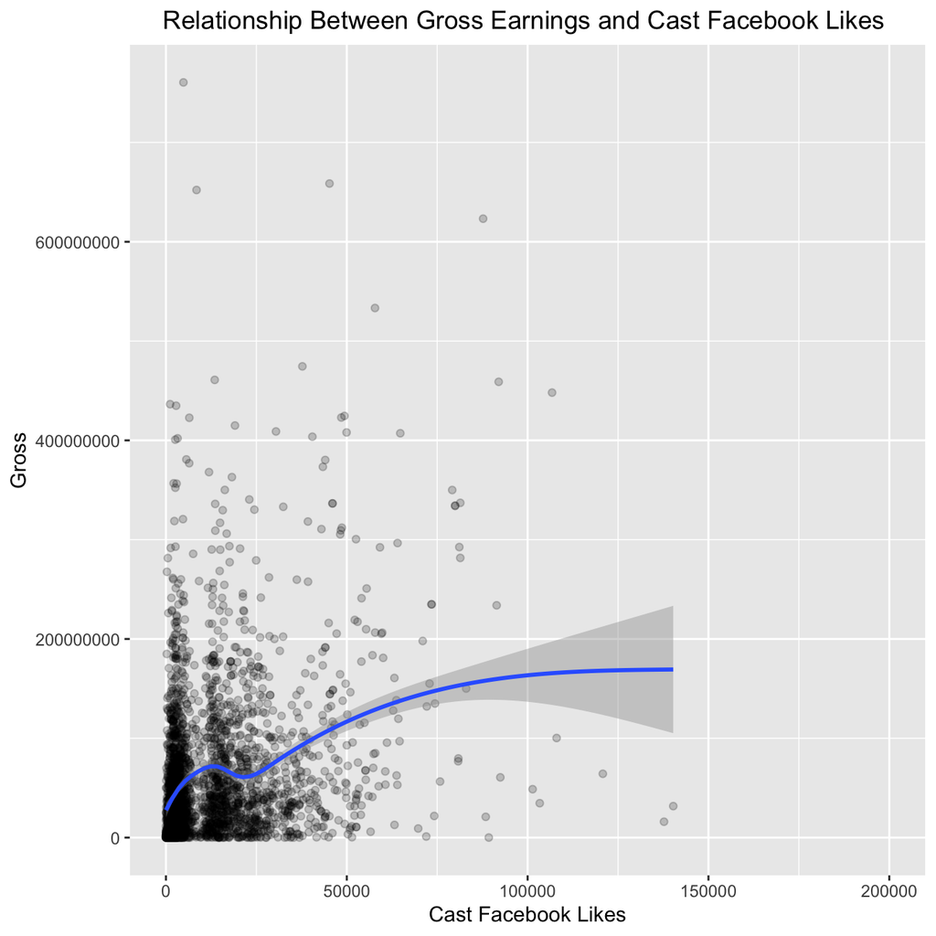

```r
# constructing a scatter plot
  ggplot(data = movies,
         mapping = aes(
           x = cast_facebook_likes,
           y = gross)) +

  # Alpha of 0.2 is used to see
  #where there is a cluster of data points on the plot.
  #As there are a few outliers,
  #the x variable of Cast Facebook Likes
  #is restricted from 0 to 200,000.
  geom_point(alpha = 0.2) +
  labs(title = "Relationship Between Gross Earnings and Cast Facebook Likes ",
       x = "Cast Facebook Likes",
       y = "Gross",
       # this forces R not to use exponential notation
       options(scipen = 999)) +
  theme(plot.title = element_text(hjust = 0.5)) +
  scale_x_continuous(limits = c(0,200000)) +
  scale_y_continuous() +
  geom_smooth() +
  NULL
```

Examining the plot, we can conclude that that Cast Facebook Likes is not a good predictor of gross movie revenue. There is no clear trend with a varying amount of movie revenue earned per amount of Facebook Cast Likes.

Let’s see if another variable portrays better correlation with gross revenue.

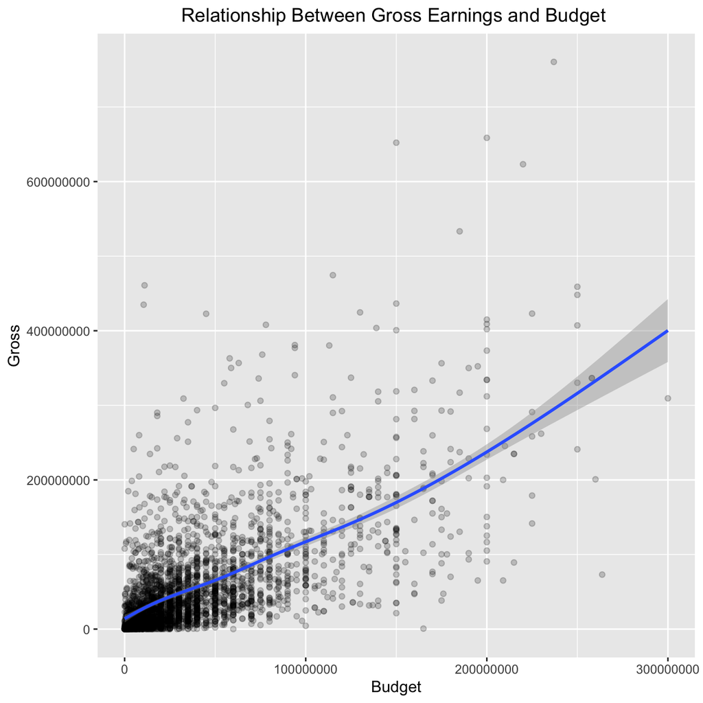

```r
# create a scatter plot for budget and gross revenue
ggplot(data = movies,
       mapping = aes(
         x = budget,
         y = gross)) +
  geom_point(alpha = 0.2) +
  labs(title = "Relationship Between Gross Earnings and Budget ",
       x = "Budget",
       y = "Gross",
       options(scipen = 999)) +
  theme(plot.title = element_text(hjust = 0.5)) +
  geom_smooth() +
  NULL
```

As seen in the plot above, budget is a better indicator to determine gross revenue for each movie, however it is far from being a perfect indicator. For each budget value, there is a wide spread of values for gross revenue. However, it is clear that with a low budget, a movie is likely to have low gross revenue.

Let us also check if ratings are a good indicator of gross revenue a movie earns.

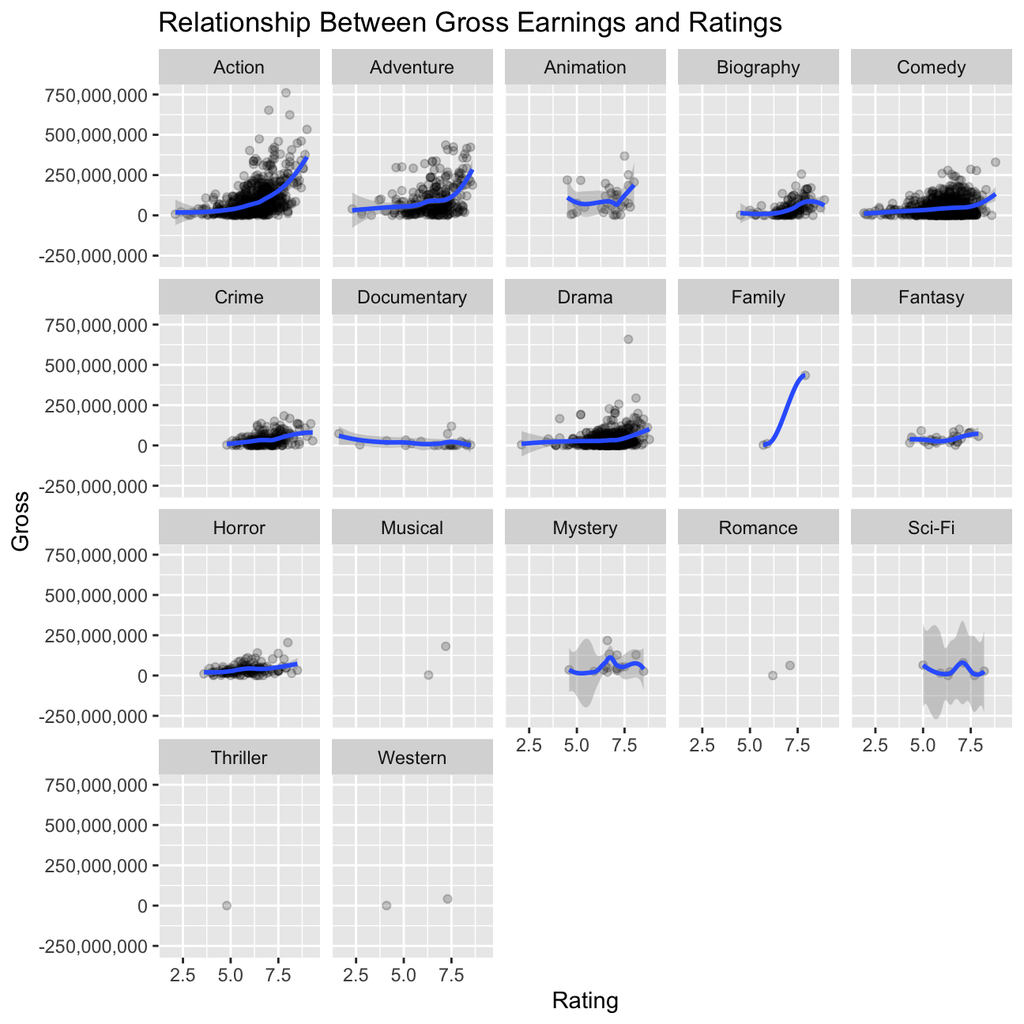

```r
# plot ratings and gross earnings of movies faceted by genre
ggplot(data = movies,
       mapping = aes(
         x = rating,
         y = gross)) +
  geom_point(alpha = 0.2) +
  labs(title = "Relationship Between Gross Earnings and Ratings ",
       x = "Rating",
       y = "Gross") +
  geom_smooth() +
  facet_wrap(~genre) +
  scale_y_continuous(labels = scales::comma) +
  NULL
```

As seen above there are varying relationships developed for IMDB rating and gross revenue for each genre.

Genres that have the largest data such as action, comedy and drama show that as ratings increase, there is more gross revenue. Action in particular highlights this relationship. However there are a few genres with limited data points where no relationship can be established such as Musical, Romance, Thriller and Western.

We think this such correlation and lack of data points also has something to do with the popularity of each genre. In less popular genres such as Documentary, irrespective of the ratings, the gross earnings remain more or less constant. In more popular genres such as Action and Adventure, higher ratings are relatively more correlated with earnings.

# Takeaway

This analytic project mainly exercises the use of:

- Function: `ggplot`, `top_n`, `arrange`, `options(scipen = 999)`.